# Assignment2

Callin Switzer

September 16, 2014

1. (5 points) Describe a situation in which you had to make a choice, and there was a correct answer that was not available as you made your choice (e.g., “take an umbrella or not”, “walk or take a T”, etc.). Think about what information you used to help you decide, and then briefly answer the questions below:
1. What was the decision about? Identify a parameter of interest that you based your decision on.

   *Once, I had to decide to plan a lesson or go to sleep (thereby not planning my lesson for the next day.) The parameter of interest was my success in teaching the following day.*
2. What were your H0 and H1 about this parameter?

   *H0: Going to sleep will help me teach better than planning my lesson* *H1: Planning my lesson will help me teach better than going to sleep*
3. Based on what quantitative or qualitative information were you deciding? *I was basing my my decision qualitative data from my own experience. I generally feel much better when I’ve had sleep, and am able to think quickly enough to teach acceptably without planning my lesson precisely. However, I was also basing my decision on my qualitative experiences that when my lessons are planned well, I teach better.*
4. What was your guess of the p-value? Did you reject your H0? *My guess of the p-value was 0.03. I rejected my null hypothesis, and decided to write the lesson plan before going to sleep*
5. What were the possible consequences of making the wrong decision?

   *The possible consequences of making the wrong decision were the following:*
   - I would be embarassed in front of students for doing a bad job at teaching.
   - My students wouldn’t learn enough material, and my principal would think I was a bad teacher.
   - My students wouldn’t do well on standardized tests, and would not get scholarships for college.
   - I would get fired from my job as a teacher.
   - I could make lots of mistakes during my class
2. (10 points) Exercise 17 in Chapter 1 (2nd or 3rd ed.).

```
## [1] "The two-sided p-value is  0.0857"
```

3. (20 points) Environmental Voting of Democrats and Republicans in the U.S. House of Representatives. Use the data provided in Problem 26, Chapter 1 (3rd ed.) to answer the following questions. Note that all calculations have to be performed in R. (First two chapters of the 3rd edition have been scanned and uploaded on the course web-site. The data file has been posted online as well.)
1. Which test is more appropriate to address the research question in this problem, permutation test or randomization test? *Research Question: Do the different parties show differences in the percentage of pro-environment votes?*

   *A permutation test is more appropriate to address the question, b/c these data are observed*
2. Based on your answer in (a), set up corresponding null and alternative hypotheses.

   *H0: The difference in the means of PctPro for republicans and democrats is 0*

   *HA: The difference in the means of PctPro for republicans and democrats is NOT 0*
3. Specify the test statistic that you are using and calculate its observed value.

   *The test statistic is mean(PctPro where Party == “R”) - mean(PctPro where Party == “D”)*

   ```
          The test statistic is -69.73
   ```

4. Draw the reference distribution of your test statistic based on 10,000 simulations. You may reuse the R code given here in Section 3.3. by adapting it to this problem.

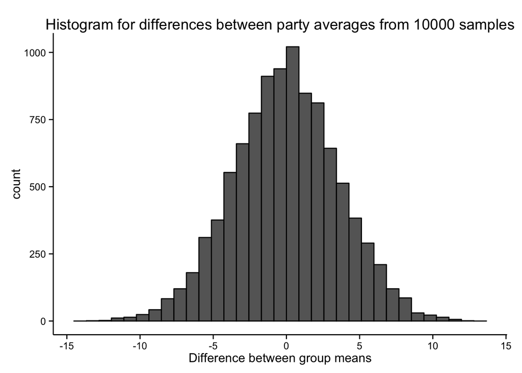